# Practica 2

## Repaso de probabilidad, Momentos y Exploración de datos masivos

## Autor: Diego Tapia

## Parte 1

### Resolver los siguientes ejercicios (paso a paso), luego resolverlos en Python y verificar resultados.

### Ejercicio 1.

Siendo X el peso Siendo X el peso de una población X1, X2, …, X10. Calcular la media, la varianza y la desviación estándar.

$X= [165.5, 175.4, 144.1, 178.5, 168, 157.9, 170.1, 202.5, 145.5, 135.7]$

### Resolución Manual:

La media $\bar{X}$ se calcula utilizando la fórmula: $ \bar{X} = \frac{1}{n} \sum_{i=1}^{n} X_i $

$ \bar{X} = \frac{1}{10} (165.5 + 175.4 + 144.1 + 178.5 + 168 + 157.9 + 170.1 + 202.5 + 145.5 + 135.7) $

$\bar{X} = 164.32 $

La varianza ($\sigma^2$) se calcula utilizando la fórmula: $ \sigma^2 = \frac{1}{n} \sum_{i=1}^{n} (X_i - \bar{X})^2 $

$ \sigma^2 = \frac{1}{10} (165.5 - 164.32)^2 + (175.4 - 164.32)^2 (144.1 - 164.32)^2 + (178.5 - 164.32)^2 (168 - 164.32)^2 (157.9 - 164.32)^2 (170.1 - 164.32)^2 (202.5 - 164.32)^2 (145.5 - 164.32)^2 (135.7 - 164.32)^2 $

$ \sigma^2 = 345.3256$

La desviación estándar ($\sigma$) es la raíz cuadrada de la varianza: $ \sigma = \sqrt{\sigma^2} = \sqrt{345.3256} $

$\sigma = 18.5829$

### Resolución en Python:

```python
import numpy as np

X = [165.5, 175.4, 144.1, 178.5, 168, 157.9, 170.1, 202.5, 145.5, 135.7]

# Convertir la lista a un array de NumPy
X_array = np.array(X)

# Calculo de la media:
media = np.mean(X_array)
print("Media:", media)

# Calculo de la varianza:
varianza = np.var(X_array, ddof=0)  # ddof=1 para calcular la varianza muestral
print("Varianza:", varianza)

# Calculo de la desviacion estandar:
desviacion_estandar = np.std(X_array, ddof=0)  # ddof=1 para calcular la desviacion estandar muestral
print("Desviación estándar:", desviacion_estandar)
```

```
Media: 164.32
Varianza: 345.32560000000007
Desviación estándar: 18.582938411349268
```

### Revisión de resultados:

|  | Resultado Manual | Resultado Python |
| --- | --- | --- |
| Media | $\bar{X} = 164.32$ | $\bar{X} = 164.32$ |
| Varianza | $\text{VAR}(X) = 345.3256$ | $\text{VAR}(X) = 345.32560000000007$ |
| Desviación estándar | $ \sigma = 18.5829$ | $ \sigma = 18.582938411349268$ |

### Ejercicio 2

$ P_{X,Y}(x,y) = \begin{cases} \frac{1}{2}, & x=1, y=4 \\ \frac{1}{3}, & x=3, y=6 \\ \frac{1}{6}, & x=5, y=8 \\ 0, & \text{otro caso} \\ \end{cases} $

Calcular la correlación $corr(X,Y)$

### Resolución Manual:

**1 Calular las Medias $\bar{X}$ y $\bar{Y}$ :**

$ \bar{X} = \sum x P_x (x) $

$ \bar{Y} = \sum y P_y (y) $

$ \bar{X} = (\frac{1}{2} \cdot 1) + (\frac{1}{3} \cdot 3) + (\frac{1}{6} \cdot 5) = \frac{7}{3} = 2.3333 $

$ \bar{Y} = (\frac{1}{2} \cdot 4) + (\frac{1}{3} \cdot 6) + (\frac{1}{6} \cdot 8) = \frac{16}{3} = 5.3333 $

**2 Calcular la covarianza $\text{Cov}(X,Y)$:**

$\text{Cov}(X, Y) = \sum_{x} \sum_{y} (x - \bar{X})(y - \bar{Y}) P_{x,y} (x,y) $

$ \text{Cov}(X, Y) = (1 - \frac{7}{3})(4 - \frac{16}{3}) \cdot \frac{1}{2} + (3 - \frac{7}{3})(6 - \frac{16}{3}) \cdot \frac{1}{3} + (5 - \frac{7}{3})(8 - \frac{16}{3}) \cdot \frac{1}{6}$

$\text{Cov}(X, Y) = \dfrac{20}{9} \approx 2.2222$

**3 Calcular las desviaciones estándar $ \sigma_{X} $ y $\sigma_{Y}$**

$ \sigma_{X} = \sqrt{ \sum_{x} (x - \bar{X})^2 P_{X}(x) } $

$ \sigma_{Y} = \sqrt{ \sum_{y} (y - \bar{Y})^2 P_{Y}(y) } $

$ \sigma_X = \sqrt{(1 - \frac{7}{3})^2 \cdot \frac{1}{2} + (3 - \frac{7}{3})^2 \cdot \frac{1}{3} + (5 - \frac{7}{3})^2 \cdot \frac{1}{6}} $

$ \sigma_X = \sqrt{(- \frac{4}{3})^2 \cdot \frac{1}{2} + ( \frac{2}{3})^2 \cdot \frac{1}{3} + ( \frac{8}{3})^2 \cdot \frac{1}{6}} $

$ \sigma_X = \sqrt{ \frac{16}{9} \cdot \frac{1}{2} + \frac{4}{9} \cdot \frac{1}{3} + \frac{67}{9} \cdot \frac{1}{6}} $

$\sigma_X = \sqrt{\frac{8}{9} + \frac{4}{27} + \frac{64}{54}} $

$\sigma_X = \sqrt{\dfrac{20}{9}} \approx 1.4907 $

$ \sigma_Y = \sqrt{(4 - \frac{16}{3})^2 \cdot \frac{1}{2} + (6 - \frac{16}{3})^2 \cdot \frac{1}{3} + (8 - \frac{16}{3})^2 \cdot \frac{1}{6}} $

$ \sigma_Y = \sqrt{(- \frac{4}{3})^2 \cdot \frac{1}{2} + ( \frac{2}{3})^2 \cdot \frac{1}{3} + ( \frac{8}{3})^2 \cdot \frac{1}{6}} $

$ \sigma_Y = \sqrt{ \frac{16}{9} \cdot \frac{1}{2} + \frac{4}{9} \cdot \frac{1}{3} + \frac{67}{9} \cdot \frac{1}{6}} $

$\sigma_Y = \sqrt{\frac{8}{9} + \frac{4}{27} + \frac{64}{54}} $

$\sigma_Y = \sqrt{\dfrac{20}{9}} \approx 1.4907 $

4 Correlacion $\text{Corr}(X,Y)$ :

$ \text{Corr}(X, Y) = \dfrac{\text{Cov}(X, Y)}{\sigma_X \sigma_Y} $

$ \text{Corr}(X, Y)= \dfrac{\frac{20}{9}}{ \sqrt{\frac{20}{9}} \sqrt{\frac{20}{9}}} $

$ \text{Corr}(X, Y)= 1 $

### Resolución en Python

```python
import numpy as np

# Definir los valores de X y Y y sus probabilidades

X = np.array([1, 3, 5])
Y = np.array([4, 6, 8])
probabilidades = np.array([1/2, 1/3, 1/6])

# Calcular la media de X e Y

media_X = np.sum(X * probabilidades)

media_Y = np.sum(Y * probabilidades)

# Calcular la covarianza de X e Y
covarianza_XY = np.sum((X - media_X) * (Y - media_Y) * probabilidades)

# Calcular las desviaciones estándar de X e Y
desviacion_estandar_X = np.sqrt(np.sum((X - media_X)**2 * probabilidades))
desviacion_estandar_Y = np.sqrt(np.sum((Y - media_Y)**2 * probabilidades))

# Calcular la correlación
correlacion_XY = covarianza_XY / (desviacion_estandar_X * desviacion_estandar_Y)

print("Correlación corr(X,Y):", correlacion_XY)
```

```
Correlación corr(X,Y): 1.0
```

### Revisión de resultados:

|  | Resultado Manual | Resultado Python |
| --- | --- | --- |
| Correlación | $ \text{Corr}(X, Y) = 1 $ | $ \text{Corr}(X, Y) = 1.0 $ |

### Ejercicio 3

Si $ M_X(s) = \dfrac{1}{4} + \dfrac{1}{2}e^s + \dfrac{1}{4}e^{2s} $, calcular $ E(X) \text{ y } \text{VAR}(X) $. Hay que recordar que la varianza es igual al segundo momento menos el cuadrado del primer momento. $ \text{VAR}(X) = E(X^2) - E(X)^2 $.

### Resolución Manual:

**Primer momento $ E(X)$ (media) :**

$ E(X) = M'_{x}(0) $

Se deriva $M_{X}(s)$ con respecto a s:

$M'_{X}(s) = \dfrac{d}{ds}(\dfrac{1}{4} + \dfrac{1}{2}e^s + \dfrac{1}{4} e^{2s})$

$M'_{X}(s) = \dfrac{1}{2}e^s + \dfrac{1}{2} e^{2s} $

$ E(X) = M'_{x}(0) = \dfrac{1}{2} + \dfrac{1}{2} = 1 $

$ E(X) = 1 $

**Segundo momento $E(X^2)$ :**

$ E(X^2) = M''_{x}(0) $

Se deriva $M'_{X}(s)$ con respecto a s:

$M''_{X}(s) = \dfrac{d}{ds}(\dfrac{1}{2}e^s + \dfrac{1}{2} e^{2s})$

$M''_{X}(s) = \dfrac{1}{2}e^s + e^{2s} $

$ E(X^2) = M''_{x}(0) = \dfrac{1}{2} + 1 $

$ E(X^2) = \dfrac{3}{2} $

**Varianza** $\text{VAR}(X)$:

$ \text{VAR}(X) = E(X^2) - E(X)^2 $

$ \text{VAR}(X) = \dfrac{3}{2} - 1^2 $

$ \text{VAR}(X) = \dfrac{1}{2} $

### Resolución en Python:

```python
import sympy as sp

s = sp.symbols('s')

# función generadora de momentos M_X(s)
M_X = 1/4 + 1/2 * sp.exp(s) + 1/4 * sp.exp(2 * s)

# Calcular E(X) primer momento
E_X = sp.diff(M_X, s).subs(s, 0)
print(f'E(X): {E_X}')

# Calcular E(X^2) segundo momento
E_X_squared = sp.diff(M_X, s, s).subs(s, 0)
print(f'E(X^2): {E_X_squared}')

# Calcular VAR(X)
VAR_X = E_X_squared - E_X**2
print(f'VAR(X): {VAR_X}')
```

```
E(X): 1.00000000000000
E(X^2): 1.50000000000000
VAR(X): 0.500000000000000
```

### Revisión de resultados:

|  | Resultado Manual | Resultado Python |
| --- | --- | --- |
| $E(X)$ | 1 | 1.0 |
| $E(X^2)$ | $\dfrac{3}{2}$ | 1.50000000000000 |
| $\text{VAR}(X)$ | $ \dfrac{1}{2}$ | 0.500000000000000 |

## Parte 2

### 4. Explorar y describir de manera general (problema, cantidad de variables, cantidad de observaciones) el dataset de Kaggle del siguiente enlace:

https://www.kaggle.com/datasets

https://www.kaggle.com/datasets/johnsmith88/heart-disease-datase

```python
import pandas as pd
import copy
# Cargar dataframe desde url de csv alojado en repositorio de github
url_dataframe = 'https://raw.githubusercontent.com/juandtap/Practica_02_analisis_multivariado_metodos_estocasticos/master/heart.csv'
# el separador es una (,) y la primera fila son los encabezados (header= 0)
dfOriginal = pd.read_csv(url_dataframe, sep=',', header=0)
dataframe = copy.deepcopy(dfOriginal)
# Se muestran las 10 primeros registros
dataframe.head(10)
```

|  | age | sex | cp | trestbps | chol | fbs | restecg | thalach | exang | oldpeak | slope | ca | thal | target |
| --- | --- | --- | --- | --- | --- | --- | --- | --- | --- | --- | --- | --- | --- | --- |
| 0 | 52 | 1 | 0 | 125 | 212 | 0 | 1 | 168 | 0 | 1.0 | 2 | 2 | 3 | 0 |
| 1 | 53 | 1 | 0 | 140 | 203 | 1 | 0 | 155 | 1 | 3.1 | 0 | 0 | 3 | 0 |
| 2 | 70 | 1 | 0 | 145 | 174 | 0 | 1 | 125 | 1 | 2.6 | 0 | 0 | 3 | 0 |
| 3 | 61 | 1 | 0 | 148 | 203 | 0 | 1 | 161 | 0 | 0.0 | 2 | 1 | 3 | 0 |
| 4 | 62 | 0 | 0 | 138 | 294 | 1 | 1 | 106 | 0 | 1.9 | 1 | 3 | 2 | 0 |
| 5 | 58 | 0 | 0 | 100 | 248 | 0 | 0 | 122 | 0 | 1.0 | 1 | 0 | 2 | 1 |
| 6 | 58 | 1 | 0 | 114 | 318 | 0 | 2 | 140 | 0 | 4.4 | 0 | 3 | 1 | 0 |
| 7 | 55 | 1 | 0 | 160 | 289 | 0 | 0 | 145 | 1 | 0.8 | 1 | 1 | 3 | 0 |
| 8 | 46 | 1 | 0 | 120 | 249 | 0 | 0 | 144 | 0 | 0.8 | 2 | 0 | 3 | 0 |
| 9 | 54 | 1 | 0 | 122 | 286 | 0 | 0 | 116 | 1 | 3.2 | 1 | 2 | 2 | 0 |

```python
cantidad_variables = dataframe.shape[1]

cantidad_observaciones = dataframe.shape[0]

print("Cantidad de variables: ",cantidad_variables)
print("Cantidad de observaciones: ", cantidad_observaciones)
```

```
Cantidad de variables:  14
Cantidad de observaciones:  1025
```

Este conjunto de datos (dataset) es de 1988 y consta de cuatro bases de datos: Cleveland, Hungría, Suiza y Long Beach V. Contiene **14 variables** (atributos), y **1025 observaciones** incluido el atributo objetivo (target). El campo "target" se refiere a la presencia de enfermedad cardíaca en el paciente. Tiene valores enteros: 0 = no enfermedad y 1 = enfermedad.

```python
dataframe.info()
```

```
<class 'pandas.core.frame.DataFrame'>
RangeIndex: 1025 entries, 0 to 1024
Data columns (total 14 columns):
 #   Column    Non-Null Count  Dtype
---  ------    --------------  -----
 0   age       1025 non-null   int64
 1   sex       1025 non-null   int64
 2   cp        1025 non-null   int64
 3   trestbps  1025 non-null   int64
 4   chol      1025 non-null   int64
 5   fbs       1025 non-null   int64
 6   restecg   1025 non-null   int64
 7   thalach   1025 non-null   int64
 8   exang     1025 non-null   int64
 9   oldpeak   1025 non-null   float64
 10  slope     1025 non-null   int64
 11  ca        1025 non-null   int64
 12  thal      1025 non-null   int64
 13  target    1025 non-null   int64
dtypes: float64(1), int64(13)
memory usage: 112.2 KB
```

### 5. Calcular la media del campo Age

```python
dataframe['age'].describe()
```

```
count    1025.000000
mean       54.434146
std         9.072290
min        29.000000
25%        48.000000
50%        56.000000
75%        61.000000
max        77.000000
Name: age, dtype: float64
```

```python
media_edad = dataframe['age'].mean()
print("Edad media: ",media_edad)
```

```
Edad media:  54.43414634146342
```

La media del campo 'Age' (edad) es de 54.4341 años.

### 6. Calcular las correlaciones entre todas las variables

```python
cr = dataframe.corr(numeric_only=True)
cr.head(15)
```

|  | age | sex | cp | trestbps | chol | fbs | restecg | thalach | exang | oldpeak | slope | ca | thal | target |
| --- | --- | --- | --- | --- | --- | --- | --- | --- | --- | --- | --- | --- | --- | --- |
| age | 1.000000 | -0.103240 | -0.071966 | 0.271121 | 0.219823 | 0.121243 | -0.132696 | -0.390227 | 0.088163 | 0.208137 | -0.169105 | 0.271551 | 0.072297 | -0.229324 |
| sex | -0.103240 | 1.000000 | -0.041119 | -0.078974 | -0.198258 | 0.027200 | -0.055117 | -0.049365 | 0.139157 | 0.084687 | -0.026666 | 0.111729 | 0.198424 | -0.279501 |
| cp | -0.071966 | -0.041119 | 1.000000 | 0.038177 | -0.081641 | 0.079294 | 0.043581 | 0.306839 | -0.401513 | -0.174733 | 0.131633 | -0.176206 | -0.163341 | 0.434854 |
| trestbps | 0.271121 | -0.078974 | 0.038177 | 1.000000 | 0.127977 | 0.181767 | -0.123794 | -0.039264 | 0.061197 | 0.187434 | -0.120445 | 0.104554 | 0.059276 | -0.138772 |
| chol | 0.219823 | -0.198258 | -0.081641 | 0.127977 | 1.000000 | 0.026917 | -0.147410 | -0.021772 | 0.067382 | 0.064880 | -0.014248 | 0.074259 | 0.100244 | -0.099966 |
| fbs | 0.121243 | 0.027200 | 0.079294 | 0.181767 | 0.026917 | 1.000000 | -0.104051 | -0.008866 | 0.049261 | 0.010859 | -0.061902 | 0.137156 | -0.042177 | -0.041164 |
| restecg | -0.132696 | -0.055117 | 0.043581 | -0.123794 | -0.147410 | -0.104051 | 1.000000 | 0.048411 | -0.065606 | -0.050114 | 0.086086 | -0.078072 | -0.020504 | 0.134468 |
| thalach | -0.390227 | -0.049365 | 0.306839 | -0.039264 | -0.021772 | -0.008866 | 0.048411 | 1.000000 | -0.380281 | -0.349796 | 0.395308 | -0.207888 | -0.098068 | 0.422895 |
| exang | 0.088163 | 0.139157 | -0.401513 | 0.061197 | 0.067382 | 0.049261 | -0.065606 | -0.380281 | 1.000000 | 0.310844 | -0.267335 | 0.107849 | 0.197201 | -0.438029 |
| oldpeak | 0.208137 | 0.084687 | -0.174733 | 0.187434 | 0.064880 | 0.010859 | -0.050114 | -0.349796 | 0.310844 | 1.000000 | -0.575189 | 0.221816 | 0.202672 | -0.438441 |
| slope | -0.169105 | -0.026666 | 0.131633 | -0.120445 | -0.014248 | -0.061902 | 0.086086 | 0.395308 | -0.267335 | -0.575189 | 1.000000 | -0.073440 | -0.094090 | 0.345512 |
| ca | 0.271551 | 0.111729 | -0.176206 | 0.104554 | 0.074259 | 0.137156 | -0.078072 | -0.207888 | 0.107849 | 0.221816 | -0.073440 | 1.000000 | 0.149014 | -0.382085 |
| thal | 0.072297 | 0.198424 | -0.163341 | 0.059276 | 0.100244 | -0.042177 | -0.020504 | -0.098068 | 0.197201 | 0.202672 | -0.094090 | 0.149014 | 1.000000 | -0.337838 |
| target | -0.229324 | -0.279501 | 0.434854 | -0.138772 | -0.099966 | -0.041164 | 0.134468 | 0.422895 | -0.438029 | -0.438441 | 0.345512 | -0.382085 | -0.337838 | 1.000000 |

### 7. Realizar un mapa de calor con los valores de las correlaciones

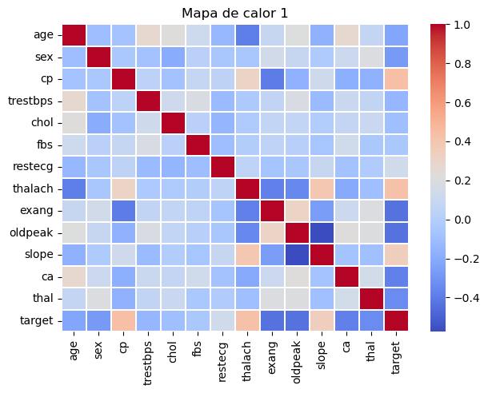

```python
import matplotlib.pyplot  as plt
import seaborn as sns

fig, ax  = plt.subplots(figsize = (7,5))
plt.title("Mapa de calor 1")
sns.heatmap(cr, cmap= "coolwarm", linewidths = 0.30, annot=False)
plt.show()
```

### 8. Determinar cuáles son las 2 variables más correlacionadas positivamente y las 2 más correlacionadas negativamente

```python
# Obtener las correlaciones positivas y negativas
correlaciones_positivas = cr.unstack().sort_values(ascending=False).drop_duplicates()
correlaciones_negativas = cr.unstack().sort_values(ascending=True).drop_duplicates()

# Eliminar las correlaciones con la misma variable
correlaciones_positivas = correlaciones_positivas[correlaciones_positivas.index.get_level_values(0) != correlaciones_positivas.index.get_level_values(1)]
correlaciones_negativas = correlaciones_negativas[correlaciones_negativas.index.get_level_values(0) != correlaciones_negativas.index.get_level_values(1)]

# Seleccionar las dos variables más correlacionadas positivamente y negativamente
top_correlaciones_positivas = correlaciones_positivas.head(2)
top_correlaciones_negativas = correlaciones_negativas.head(2)

# Mostrar los resultados
print("Variables más correlacionadas positivamente:")
print(top_correlaciones_positivas)

print("\nVariables más correlacionadas negativamente:")
print(top_correlaciones_negativas)
```

```
Variables más correlacionadas positivamente:
target   cp        0.434854
thalach  target    0.422895
dtype: float64

Variables más correlacionadas negativamente:
slope   oldpeak   -0.575189
target  oldpeak   -0.438441
dtype: float64
```

### 9. Analizar los datos que se presenta en:

http://www.internetlivestats.com/

La tabla a continuación muestran la cantidad de usuarios globales de Internet por año desde el 2000.

```python
# carga de datos de internetlivestats.com
# Cargar dataframe desde url de csv alojado en repositorio de github
url_dataframe = 'https://raw.githubusercontent.com/juandtap/Practica_02_analisis_multivariado_metodos_estocasticos/master/data_internet.csv'
# el separador es una (;) y la primera fila son los encabezados (header= 0)
dfOriginal = pd.read_csv(url_dataframe, sep=';', header=0)
dataframe_internet = copy.deepcopy(dfOriginal)
# Se muestran todos los registros
dataframe_internet.head(17)
```

|  | Year | Internet Users | Penetration (% of Pop) | World Population | Non-Users | 1Y User % | 1Y User | World Pop % |
| --- | --- | --- | --- | --- | --- | --- | --- | --- |
| 0 | 2016 | 3424971237 | 46.1 | 7432663275 | 4007692038 | 7.5 | 238975082 | 1.13 |
| 1 | 2015 | 3185996155 | 43.4 | 7349472099 | 4163475944 | 7.8 | 229610586 | 1.15 |
| 2 | 2014 | 2956385569 | 40.7 | 7265785946 | 4309400377 | 8.4 | 227957462 | 1.17 |
| 3 | 2013 | 2728428107 | 3800.0 | 7181715139 | 4453287032 | 9.4 | 233691859 | 1.19 |
| 4 | 2012 | 2494736248 | 35.1 | 7097500453 | 4602764205 | 11.8 | 262778889 | 1.20 |
| 5 | 2011 | 2231957359 | 31.8 | 7013427052 | 4781469693 | 10.3 | 208754385 | 1.21 |
| 6 | 2010 | 2023202974 | 29.2 | 6929725043 | 4906522069 | 14.5 | 256799160 | 1.22 |
| 7 | 2009 | 1766403814 | 25.8 | 6846479521 | 5080075707 | 12.1 | 191336294 | 1.22 |
| 8 | 2008 | 1575067520 | 23.3 | 6763732879 | 5188665359 | 14.7 | 201840532 | 1.23 |
| 9 | 2007 | 1373226988 | 20.6 | 6681607320 | 5308380332 | 18.1 | 210310170 | 1.23 |
| 10 | 2006 | 1162916818 | 17.6 | 6600220247 | 5437303429 | 12.9 | 132815529 | 1.24 |
| 11 | 2005 | 1030101289 | 15.8 | 6519635850 | 5489534561 | 12.8 | 116773518 | 1.24 |
| 12 | 2004 | 913327771 | 14.2 | 6439842408 | 5526514637 | 16.9 | 131891788 | 1.24 |
| 13 | 2003 | 781435983 | 12.3 | 6360764684 | 5579328701 | 17.5 | 116370969 | 1.25 |
| 14 | 2002 | 665065014 | 10.6 | 6282301767 | 5617236753 | 32.4 | 162772769 | 1.26 |
| 15 | 2001 | 502292245 | 8.1 | 6204310739 | 5702018494 | 21.1 | 87497288 | 1.27 |
| 16 | 2000 | 414794957 | 6.8 | 6126622121 | 5711827164 | 47.3 | 133257305 | 1.28 |

```python
dataframe_internet.info()
```

```
<class 'pandas.core.frame.DataFrame'>
RangeIndex: 17 entries, 0 to 16
Data columns (total 8 columns):
 #   Column                  Non-Null Count  Dtype
---  ------                  --------------  -----
 0   Year                    17 non-null     int64
 1   Internet Users          17 non-null     int64
 2   Penetration (% of Pop)  17 non-null     float64
 3   World Population        17 non-null     int64
 4   Non-Users               17 non-null     int64
 5   1Y User %               17 non-null     float64
 6   1Y User                 17 non-null     int64
 7   World Pop %             17 non-null     float64
dtypes: float64(3), int64(5)
memory usage: 1.2 KB
```

### Resumen estadistico

Se calcula las medidas descriptivas de las variables que tienen formato numérico

```python
dataframe_internet.describe()
```

|  | Year | Internet Users | Penetration (% of Pop) | World Population | Non-Users | 1Y User % | 1Y User | World Pop % |
| --- | --- | --- | --- | --- | --- | --- | --- | --- |
| count | 17.000000 | 1.700000e+01 | 17.000000 | 1.700000e+01 | 1.700000e+01 | 17.000000 | 1.700000e+01 | 17.000000 |
| mean | 2008.000000 | 1.719430e+09 | 245.964706 | 6.770342e+09 | 5.050912e+09 | 16.205882 | 1.849079e+08 | 1.219412 |
| std | 5.049752 | 9.784071e+08 | 915.937148 | 4.135005e+08 | 5.696396e+08 | 10.035404 | 5.558746e+07 | 0.040999 |
| min | 2000.000000 | 4.147950e+08 | 6.800000 | 6.126622e+09 | 4.007692e+09 | 7.500000 | 8.749729e+07 | 1.130000 |
| 25% | 2004.000000 | 9.133278e+08 | 14.200000 | 6.439842e+09 | 4.602764e+09 | 10.300000 | 1.328155e+08 | 1.200000 |
| 50% | 2008.000000 | 1.575068e+09 | 23.300000 | 6.763733e+09 | 5.188665e+09 | 12.900000 | 2.018405e+08 | 1.230000 |
| 75% | 2012.000000 | 2.494736e+09 | 35.100000 | 7.097500e+09 | 5.526515e+09 | 17.500000 | 2.296106e+08 | 1.240000 |
| max | 2016.000000 | 3.424971e+09 | 3800.000000 | 7.432663e+09 | 5.711827e+09 | 47.300000 | 2.627789e+08 | 1.280000 |

### Grafica de número de usuarios globales de internet por año desde el año 2000.

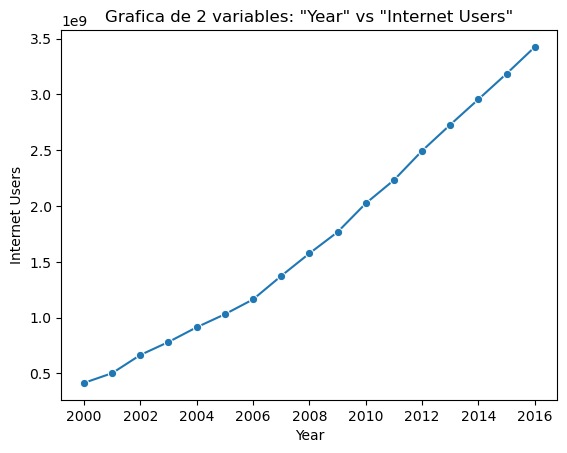

```python
import seaborn as sns
variable1 = 'Year'
variable2 = 'Internet Users'

# Extraer datos de las variables
x = dataframe_internet[variable1]
y = dataframe_internet[variable2]

sns.lineplot(x = x,  y= y,marker = "o")

# Agregar etiquetas y título
plt.xlabel(variable1)
plt.ylabel(variable2)
plt.title('Grafica de 2 variables: "{}" vs "{}"'.format(variable1, variable2))


# Mostrar el gráfico
plt.show()
```

### Análisis de correlación

#### Análisis de correlación entre todas las variables

```python
cr2 = dataframe_internet.corr(numeric_only=True)
cr2.head(8)
```

|  | Year | Internet Users | Penetration (% of Pop) | World Population | Non-Users | 1Y User % | 1Y User | World Pop % |
| --- | --- | --- | --- | --- | --- | --- | --- | --- |
| Year | 1.000000 | 0.991699 | 0.268101 | 0.999904 | -0.977502 | -0.772920 | 0.856495 | -0.959994 |
| Internet Users | 0.991699 | 1.000000 | 0.278712 | 0.993364 | -0.996509 | -0.715946 | 0.845800 | -0.972716 |
| Penetration (% of Pop) | 0.268101 | 0.278712 | 1.000000 | 0.269327 | -0.283210 | -0.184294 | 0.237253 | -0.197701 |
| World Population | 0.999904 | 0.993364 | 0.269327 | 1.000000 | -0.980292 | -0.767440 | 0.855639 | -0.962036 |
| Non-Users | -0.977502 | -0.996509 | -0.283210 | -0.980292 | 1.000000 | 0.672617 | -0.831631 | 0.972387 |
| 1Y User % | -0.772920 | -0.715946 | -0.184294 | -0.767440 | 0.672617 | 1.000000 | -0.480346 | 0.728249 |
| 1Y User | 0.856495 | 0.845800 | 0.237253 | 0.855639 | -0.831631 | -0.480346 | 1.000000 | -0.750319 |
| World Pop % | -0.959994 | -0.972716 | -0.197701 | -0.962036 | 0.972387 | 0.728249 | -0.750319 | 1.000000 |

#### Mapa de calor

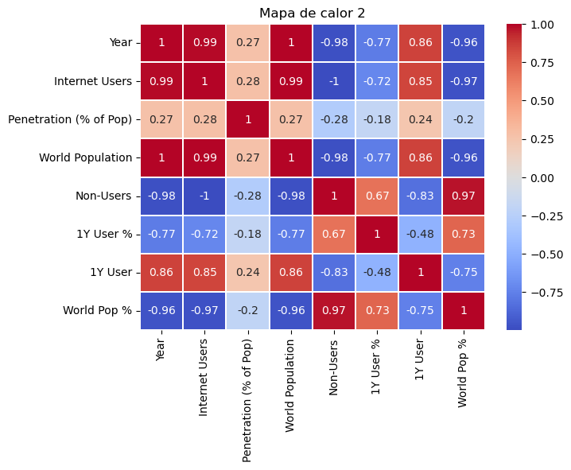

```python
fig, ax  = plt.subplots(figsize = (7,5))
plt.title("Mapa de calor 2")
sns.heatmap(cr2, cmap= "coolwarm", linewidths = 0.30, annot=True)
plt.show()
```

## Conlusiones

Utilizar Python con Jupyter Notebooks es muy útil para el análisis de datos y los cálculos matemáticos. Gracias a librerías como NumPy y Pandas, se pueden realizar fácilmente cálculos matemáticos y estadísticos, manipulación de datos y visualización. Mediante el análisis exploratorio, se puede obtener fácilmente la media y la desviación típica de cada variable, así como las correlaciones y su mapa de calor. Con esta información, podemos establecer nuestras primeras conclusiones sobre el conjunto de datos analizado.

## Referencias

[1] D. Lapp, “Heart Disease Dataset”, 06-jun-2019. [En línea]. Disponible en: https://www.kaggle.com/datasets/johnsmith88/heart-disease-dataset. [Consultado: 18-nov-2023].

[2] “Internet live stats - Internet usage & social media statistics”, Internetlivestats.com. [En línea]. Disponible en: https://www.internetlivestats.com/. [Consultado: 18-nov-2023].